# Custom Convolutional Neural Networks

### Authors:

- Izquierdo Alvarez, Mario
- Romero Romero, Martín

This notebook is focus on building and training several custom Convolutional Neural Networks of increasing complexity, trying to achieve the best results possible on the Animals dataset.

#### Index

- Some utility functions
- Some global variables
- Loading datasets
- Simple CNN - No regularization
- Some regularization - Dropout and batch-normalization
- L2 Regularization + Batch Normalization + Data augmentation
- Custom ResNet + bn + l2

```python
import os
import keras
import tensorflow as tf
import numpy as np
from tensorflow.keras.utils import image_dataset_from_directory
import matplotlib.pyplot as plt

from tensorflow import keras
from tensorflow.keras import layers
from keras.regularizers import l2

from rich import print
```

## Some utility functions

```python
def plot(history):
    accuracy = history.history['accuracy']
    val_accuracy = history.history['val_accuracy']
    loss = history.history['loss']
    val_loss = history.history['val_loss']

    epochs = range(1, len(accuracy) + 1)

    # Create subplots and unpack the axes array immediately
    fig, (ax_accuracy, ax_loss) = plt.subplots(1, 2, figsize=(20, 6))  # figsize=(width, height) in inches

    # Plot training and validation accuracy on the first axis
    ax_accuracy.plot(epochs, accuracy, 'b-o', label='Training accuracy')
    ax_accuracy.plot(epochs, val_accuracy, 'r-o', label='Validation accuracy')
    ax_accuracy.set_title('Training and Validation Accuracy')
    ax_accuracy.legend()
    ax_accuracy.set_xlabel('Epoch')
    ax_accuracy.set_ylabel('Accuracy')

    # Plot training and validation loss on the second axis
    ax_loss.plot(epochs, loss, 'b-o', label='Training loss')
    ax_loss.plot(epochs, val_loss, 'r-o', label='Validation loss')
    ax_loss.set_title('Training and Validation Loss')
    ax_loss.legend()
    ax_loss.set_xlabel('Epoch')
    ax_loss.set_ylabel('Loss')

    # Display the plot
    plt.show()
```

```python
def save_model_results(file_path, model_name, accuracy):
    """
    This function saves the model's accuracy to a CSV file. It checks if the file exists
    to add a header if necessary and then opens the file in append mode to add
    the model name and accuracy.
    """
    # Check if the file exists to decide on adding the header
    header_needed = not os.path.isfile(file_path)

    # Open the file in append mode, which creates the file if it doesn't exist
    with open(file_path, "a") as file:
        # Add a header if the file was just created
        if header_needed:
            file.write("model_name,accuracy\n")
        # Append the model name and accuracy to the file
        file.write(f"{model_name},{accuracy:.3f}\n")
```

## Some global variables

- Using an image size of **(512, 512)** as explained on `data_exploration.ipynb`
- **Batch size:** The training of these models is going to be done on a **GPU**. A way to speed up the training, reducing the number of weight updates per epoch, is increasing the batch size. However, this implies **higher VRAM** requirements, due to **limited VRAM** the batch size cannot be very big, so it's set to **32**.

```python
val_results_path = "val_results.csv"
test_results_path = "test_results.csv"
```

```python
img_size = 512
image_size = (img_size, img_size)
img_tensor_shape = (img_size, img_size, 3)
batch_size = 32
```

## Loading datasets

```python
train_dataset = image_dataset_from_directory(
    '../data/new_data/train',
    image_size = image_size,
    batch_size = batch_size)
test_dataset = image_dataset_from_directory(
    '../data/new_data/test',
    image_size = image_size,
    batch_size=batch_size)
val_dataset = image_dataset_from_directory(
    '../data/new_data/validation',
    image_size = image_size,
    batch_size=batch_size)
```

```
Found 10778 files belonging to 5 classes.
Found 1497 files belonging to 5 classes.
Found 2696 files belonging to 5 classes.
```

```python
class_names = train_dataset.class_names
class_names
```

```
['cat', 'dog', 'elephant', 'horse', 'lion']
```

## Simple CNN + DropOut + Early Stopping

Simple CNN model with **few** convolutional layers and **slight regularization**. **Early stopping** is used to stop the training when validation loss stops improving.

### Building Model

```python
inputs = keras.Input(shape=img_tensor_shape)
# Rescale images to [0, 1]
x = layers.Rescaling(1./255)(inputs)

x = layers.Conv2D(filters=32, kernel_size=3, activation="relu")(x)
x = layers.MaxPooling2D(pool_size=2)(x)  # First MaxPooling layer

x = layers.Conv2D(filters=64, kernel_size=3, activation="relu")(x)
x = layers.MaxPooling2D(pool_size=2)(x)  # Second MaxPooling layer

x = layers.Conv2D(filters=128, kernel_size=3, activation="relu")(x)
x = layers.MaxPooling2D(pool_size=2)(x)  # Third MaxPooling layer

x = layers.Conv2D(filters=256, kernel_size=3, activation="relu")(x)
x = layers.MaxPooling2D(pool_size=2)(x)  # Fourth MaxPooling layer

x = layers.Conv2D(filters=256, kernel_size=3, activation="relu")(x)
x = layers.Flatten()(x)  # Flatten the output to feed into a dense layer

# Adding some dense layers
x = layers.Dense(512, activation="relu")(x)
x = layers.Dropout(0.5)(x)  # Adding dropout for regularization
x = layers.Dense(256, activation="relu")(x)

# Output layer for 5 classes
outputs = layers.Dense(5, activation="softmax")(x)

model = keras.Model(inputs=inputs, outputs=outputs)
```

```python
# Compiling the model with sparse_categorical_crossentropy suitable for multi-class classification with integer labels
model.compile(optimizer='adam',
              loss='sparse_categorical_crossentropy',
              metrics=['accuracy'])

# Model summary to see the architecture
model.summary()
```

```
Model: "functional_1"
```

```
┏━━━━━━━━━━━━━━━━━━━━━━━━━━━━━━━━━┳━━━━━━━━━━━━━━━━━━━━━━━━━━━┳━━━━━━━━━━━━┓
┃ Layer (type)                    ┃ Output Shape              ┃    Param # ┃
┡━━━━━━━━━━━━━━━━━━━━━━━━━━━━━━━━━╇━━━━━━━━━━━━━━━━━━━━━━━━━━━╇━━━━━━━━━━━━┩
│ input_layer (InputLayer)        │ (None, 512, 512, 3)       │          0 │
├─────────────────────────────────┼───────────────────────────┼────────────┤
│ rescaling (Rescaling)           │ (None, 512, 512, 3)       │          0 │
├─────────────────────────────────┼───────────────────────────┼────────────┤
│ conv2d (Conv2D)                 │ (None, 510, 510, 32)      │        896 │
├─────────────────────────────────┼───────────────────────────┼────────────┤
│ max_pooling2d (MaxPooling2D)    │ (None, 255, 255, 32)      │          0 │
├─────────────────────────────────┼───────────────────────────┼────────────┤
│ conv2d_1 (Conv2D)               │ (None, 253, 253, 64)      │     18,496 │
├─────────────────────────────────┼───────────────────────────┼────────────┤
│ max_pooling2d_1 (MaxPooling2D)  │ (None, 126, 126, 64)      │          0 │
├─────────────────────────────────┼───────────────────────────┼────────────┤
│ conv2d_2 (Conv2D)               │ (None, 124, 124, 128)     │     73,856 │
├─────────────────────────────────┼───────────────────────────┼────────────┤
│ max_pooling2d_2 (MaxPooling2D)  │ (None, 62, 62, 128)       │          0 │
├─────────────────────────────────┼───────────────────────────┼────────────┤
│ conv2d_3 (Conv2D)               │ (None, 60, 60, 256)       │    295,168 │
├─────────────────────────────────┼───────────────────────────┼────────────┤
│ max_pooling2d_3 (MaxPooling2D)  │ (None, 30, 30, 256)       │          0 │
├─────────────────────────────────┼───────────────────────────┼────────────┤
│ conv2d_4 (Conv2D)               │ (None, 28, 28, 256)       │    590,080 │
├─────────────────────────────────┼───────────────────────────┼────────────┤
│ flatten (Flatten)               │ (None, 200704)            │          0 │
├─────────────────────────────────┼───────────────────────────┼────────────┤
│ dense (Dense)                   │ (None, 512)               │ 102,760,9… │
├─────────────────────────────────┼───────────────────────────┼────────────┤
│ dropout (Dropout)               │ (None, 512)               │          0 │
├─────────────────────────────────┼───────────────────────────┼────────────┤
│ dense_1 (Dense)                 │ (None, 256)               │    131,328 │
├─────────────────────────────────┼───────────────────────────┼────────────┤
│ dense_2 (Dense)                 │ (None, 5)                 │      1,285 │
└─────────────────────────────────┴───────────────────────────┴────────────┘
```

```
 Total params: 103,872,069 (396.24 MB)
```

```
 Trainable params: 103,872,069 (396.24 MB)
```

```
 Non-trainable params: 0 (0.00 B)
```

### Training

```python
model_name = 'custom_simple_cnn'
```

```python
callbacks = [
    # ModelCheckpoint to save the model after every epoch if val_loss improves
    keras.callbacks.ModelCheckpoint(
        filepath="models/"+model_name+".keras",
        save_best_only=True,  # Only save a model if `val_loss` has improved
        monitor="val_loss"
    ),
    # EarlyStopping to stop training when `val_loss` is not improving
    keras.callbacks.EarlyStopping(
        monitor="val_loss",
        patience=10,
        restore_best_weights=True
    )
]

history = model.fit(
    train_dataset,
    epochs=60,
    validation_data=val_dataset,
    callbacks=callbacks
)
```

```
337/337 ━━━━━━━━━━━━━━━━━━━━ 79s 177ms/step - accuracy: 0.3334 - loss: 1.6120 - val_accuracy: 0.6803 - val_loss: 0.7853
337/337 ━━━━━━━━━━━━━━━━━━━━ 43s 126ms/step - accuracy: 0.6913 - loss: 0.7266 - val_accuracy: 0.7474 - val_loss: 0.6174
337/337 ━━━━━━━━━━━━━━━━━━━━ 43s 126ms/step - accuracy: 0.7407 - loss: 0.6019 - val_accuracy: 0.7697 - val_loss: 0.5998
337/337 ━━━━━━━━━━━━━━━━━━━━ 41s 121ms/step - accuracy: 0.7757 - loss: 0.5208 - val_accuracy: 0.7634 - val_loss: 0.6295
337/337 ━━━━━━━━━━━━━━━━━━━━ 41s 121ms/step - accuracy: 0.8150 - loss: 0.4612 - val_accuracy: 0.7767 - val_loss: 0.6321
337/337 ━━━━━━━━━━━━━━━━━━━━ 42s 125ms/step - accuracy: 0.8512 - loss: 0.3734 - val_accuracy: 0.8019 - val_loss: 0.5983
337/337 ━━━━━━━━━━━━━━━━━━━━ 41s 121ms/step - accuracy: 0.8977 - loss: 0.2733 - val_accuracy: 0.7934 - val_loss: 0.6670
337/337 ━━━━━━━━━━━━━━━━━━━━ 41s 121ms/step - accuracy: 0.9174 - loss: 0.2223 - val_accuracy: 0.7938 - val_loss: 0.7135
337/337 ━━━━━━━━━━━━━━━━━━━━ 41s 121ms/step - accuracy: 0.9408 - loss: 0.1709 - val_accuracy: 0.7849 - val_loss: 0.8619
337/337 ━━━━━━━━━━━━━━━━━━━━ 41s 121ms/step - accuracy: 0.9525 - loss: 0.1368 - val_accuracy: 0.7752 - val_loss: 0.9162
337/337 ━━━━━━━━━━━━━━━━━━━━ 41s 122ms/step - accuracy: 0.9635 - loss: 0.1138 - val_accuracy: 0.8071 - val_loss: 0.8587
337/337 ━━━━━━━━━━━━━━━━━━━━ 41s 121ms/step - accuracy: 0.9790 - loss: 0.0643 - val_accuracy: 0.7674 - val_loss: 1.3499
337/337 ━━━━━━━━━━━━━━━━━━━━ 41s 121ms/step - accuracy: 0.9652 - loss: 0.1027 - val_accuracy: 0.8027 - val_loss: 1.0653
337/337 ━━━━━━━━━━━━━━━━━━━━ 41s 122ms/step - accuracy: 0.9793 - loss: 0.0662 - val_accuracy: 0.8042 - val_loss: 0.8664
337/337 ━━━━━━━━━━━━━━━━━━━━ 41s 121ms/step - accuracy: 0.9859 - loss: 0.0440 - val_accuracy: 0.8016 - val_loss: 0.9525
337/337 ━━━━━━━━━━━━━━━━━━━━ 41s 122ms/step - accuracy: 0.9824 - loss: 0.0561 - val_accuracy: 0.8105 - val_loss: 1.0924
```

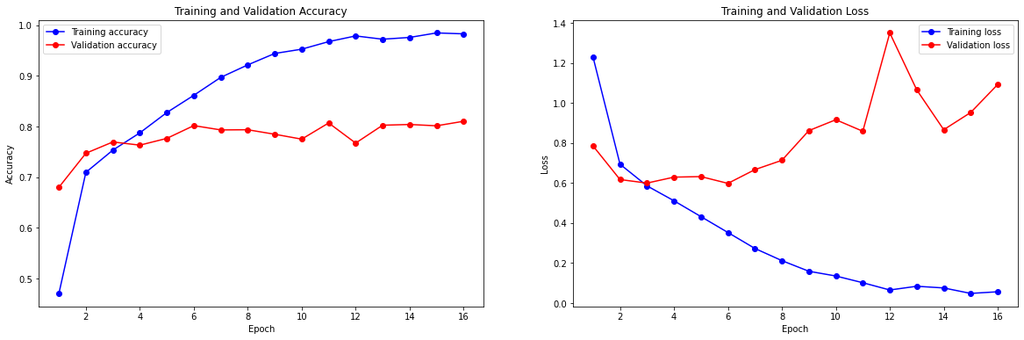

```python
plot(history)
```

```python
# Save and show validatin results
val_loss, val_acc = model.evaluate(val_dataset)

save_model_results(val_results_path, model_name, val_acc)

# Save test results for latter analysis

# model = keras.models.load_model("convnet_from_scratch.keras")
test_loss, test_acc = model.evaluate(test_dataset)
save_model_results(test_results_path, model_name, test_acc)

print(f"\nValidation accuracy: {val_acc:.3f}")
```

```
85/85 ━━━━━━━━━━━━━━━━━━━━ 3s 38ms/step - accuracy: 0.8082 - loss: 0.6078
47/47 ━━━━━━━━━━━━━━━━━━━━ 2s 36ms/step - accuracy: 0.8163 - loss: 0.4967
```

```
Validation accuracy: 0.802
```

### Discussion of Results

The results obtained from this model demonstrate a decent accuracy rate of **0.802** in validation. However, as evident from the plots, the model quickly begins to **overfit** the data. While the training loss shows improvement, the validation loss **stagnate** and gradually **deteriorates**. To address this, the next steps will involve developing more complex models but with **stronger regularization** techniques to prevent overfitting.

## Some regularization - Dropout and batch-normalization

This model incorporates **Dropout** and **Batch Normalization** as key regularization techniques to enhance performance and prevent overfitting. Despite concerns that **Dropout may interfere** with Batch Normalization's effectiveness, their combined use has been shown to support better generalization in many **successful models**. Dropout reduces over-reliance on specific neurons by randomly disabling them during training, while Batch Normalization ensures stable learning by normalizing the inputs across mini-batches. Together, these strategies aim to improve the model's robustness and efficiency in learning from complex datasets.

```python
inputs = keras.Input(shape=img_tensor_shape)  # Ensure img_tensor_shape is defined, e.g., (height, width, channels)
# Rescale images to [0, 1]
x = layers.Rescaling(1./255)(inputs)

# Convolutional block 1
x = layers.Conv2D(filters=32, kernel_size=3)(x)  # Removed activation
x = layers.BatchNormalization()(x)  # Batch normalization
x = layers.Activation("relu")(x)  # Activation after batch normalization
x = layers.MaxPooling2D(pool_size=2)(x)

# Convolutional block 2
x = layers.Conv2D(filters=64, kernel_size=3)(x)
x = layers.BatchNormalization()(x)
x = layers.Activation("relu")(x)
x = layers.MaxPooling2D(pool_size=2)(x)

# Convolutional block 3
x = layers.Conv2D(filters=128, kernel_size=3)(x)
x = layers.BatchNormalization()(x)
x = layers.Activation("relu")(x)
x = layers.MaxPooling2D(pool_size=2)(x)

# Convolutional block 4
x = layers.Conv2D(filters=256, kernel_size=3)(x)
x = layers.BatchNormalization()(x)
x = layers.Activation("relu")(x)
x = layers.MaxPooling2D(pool_size=2)(x)

# Convolutional block 5
x = layers.Conv2D(filters=256, kernel_size=3)(x)
x = layers.BatchNormalization()(x)
x = layers.Activation("relu")(x)
x = layers.Flatten()(x)  # Flatten the output to feed into a dense layer

# Dense block 1
x = layers.Dense(512)(x)  # Removed activation
x = layers.BatchNormalization()(x)
x = layers.Activation("relu")(x)
x = layers.Dropout(0.5)(x)  # Dropout for regularization

# Dense block 2
x = layers.Dense(256)(x)  # Removed activation
x = layers.BatchNormalization()(x)
x = layers.Activation("relu")(x)
x = layers.Dropout(0.5)(x)

# Dense block 3
x = layers.Dense(128)(x)  # Removed activation
x = layers.BatchNormalization()(x)
x = layers.Activation("relu")(x)

# Output layer for 5 classes
outputs = layers.Dense(5, activation="softmax")(x)

model = keras.Model(inputs=inputs, outputs=outputs)
```

```python
# Compiling the model with sparse_categorical_crossentropy suitable for multi-class classification with integer labels
model.compile(optimizer='adam',
              loss='sparse_categorical_crossentropy',
              metrics=['accuracy'])

# Model summary to see the architecture
model.summary()
```

```
Model: "functional_1"
```

```
┏━━━━━━━━━━━━━━━━━━━━━━━━━━━━━━━━━┳━━━━━━━━━━━━━━━━━━━━━━━━━━━┳━━━━━━━━━━━━┓
┃ Layer (type)                    ┃ Output Shape              ┃    Param # ┃
┡━━━━━━━━━━━━━━━━━━━━━━━━━━━━━━━━━╇━━━━━━━━━━━━━━━━━━━━━━━━━━━╇━━━━━━━━━━━━┩
│ input_layer (InputLayer)        │ (None, 512, 512, 3)       │          0 │
├─────────────────────────────────┼───────────────────────────┼────────────┤
│ rescaling (Rescaling)           │ (None, 512, 512, 3)       │          0 │
├─────────────────────────────────┼───────────────────────────┼────────────┤
│ conv2d (Conv2D)                 │ (None, 510, 510, 32)      │        896 │
├─────────────────────────────────┼───────────────────────────┼────────────┤
│ batch_normalization             │ (None, 510, 510, 32)      │        128 │
│ (BatchNormalization)            │                           │            │
├─────────────────────────────────┼───────────────────────────┼────────────┤
│ activation (Activation)         │ (None, 510, 510, 32)      │          0 │
├─────────────────────────────────┼───────────────────────────┼────────────┤
│ max_pooling2d (MaxPooling2D)    │ (None, 255, 255, 32)      │          0 │
├─────────────────────────────────┼───────────────────────────┼────────────┤
│ conv2d_1 (Conv2D)               │ (None, 253, 253, 64)      │     18,496 │
├─────────────────────────────────┼───────────────────────────┼────────────┤
│ batch_normalization_1           │ (None, 253, 253, 64)      │        256 │
│ (BatchNormalization)            │                           │            │
├─────────────────────────────────┼───────────────────────────┼────────────┤
│ activation_1 (Activation)       │ (None, 253, 253, 64)      │          0 │
├─────────────────────────────────┼───────────────────────────┼────────────┤
│ max_pooling2d_1 (MaxPooling2D)  │ (None, 126, 126, 64)      │          0 │
├─────────────────────────────────┼───────────────────────────┼────────────┤
│ conv2d_2 (Conv2D)               │ (None, 124, 124, 128)     │     73,856 │
├─────────────────────────────────┼───────────────────────────┼────────────┤
│ batch_normalization_2           │ (None, 124, 124, 128)     │        512 │
│ (BatchNormalization)            │                           │            │
├─────────────────────────────────┼───────────────────────────┼────────────┤
│ activation_2 (Activation)       │ (None, 124, 124, 128)     │          0 │
├─────────────────────────────────┼───────────────────────────┼────────────┤
│ max_pooling2d_2 (MaxPooling2D)  │ (None, 62, 62, 128)       │          0 │
├─────────────────────────────────┼───────────────────────────┼────────────┤
│ conv2d_3 (Conv2D)               │ (None, 60, 60, 256)       │    295,168 │
├─────────────────────────────────┼───────────────────────────┼────────────┤
│ batch_normalization_3           │ (None, 60, 60, 256)       │      1,024 │
│ (BatchNormalization)            │                           │            │
├─────────────────────────────────┼───────────────────────────┼────────────┤
│ activation_3 (Activation)       │ (None, 60, 60, 256)       │          0 │
```

[output cut: 24 more lines]

```
│ (BatchNormalization)            │                           │            │
├─────────────────────────────────┼───────────────────────────┼────────────┤
│ activation_6 (Activation)       │ (None, 256)               │          0 │
├─────────────────────────────────┼───────────────────────────┼────────────┤
│ dropout_1 (Dropout)             │ (None, 256)               │          0 │
├─────────────────────────────────┼───────────────────────────┼────────────┤
│ dense_2 (Dense)                 │ (None, 128)               │     32,896 │
├─────────────────────────────────┼───────────────────────────┼────────────┤
│ batch_normalization_7           │ (None, 128)               │        512 │
│ (BatchNormalization)            │                           │            │
├─────────────────────────────────┼───────────────────────────┼────────────┤
│ activation_7 (Activation)       │ (None, 128)               │          0 │
├─────────────────────────────────┼───────────────────────────┼────────────┤
│ dense_3 (Dense)                 │ (None, 5)                 │        645 │
└─────────────────────────────────┴───────────────────────────┴────────────┘
```

```
 Total params: 103,910,853 (396.39 MB)
```

```
 Trainable params: 103,907,589 (396.38 MB)
```

```
 Non-trainable params: 3,264 (12.75 KB)
```

```python
model_name = 'custom_dp_bn_256'
```

```python
callbacks = [
    # ModelCheckpoint to save the model after every epoch if val_loss improves
    keras.callbacks.ModelCheckpoint(
        filepath="models/"+model_name+".keras",
        save_best_only=True,  # Only save a model if `val_loss` has improved
        monitor="val_loss"
    ),
    # EarlyStopping to stop training when `val_loss` is not improving
    keras.callbacks.EarlyStopping(
        monitor="val_loss",
        patience=10,
        restore_best_weights=True
    )
]

history = model.fit(
    train_dataset,
    epochs=60,
    validation_data=val_dataset,
    callbacks=callbacks
)
```

```
337/337 ━━━━━━━━━━━━━━━━━━━━ 93s 214ms/step - accuracy: 0.5350 - loss: 1.1336 - val_accuracy: 0.2767 - val_loss: 4.0184
337/337 ━━━━━━━━━━━━━━━━━━━━ 54s 161ms/step - accuracy: 0.7497 - loss: 0.6327 - val_accuracy: 0.6632 - val_loss: 0.8571
337/337 ━━━━━━━━━━━━━━━━━━━━ 53s 158ms/step - accuracy: 0.7802 - loss: 0.5587 - val_accuracy: 0.6784 - val_loss: 0.8977
337/337 ━━━━━━━━━━━━━━━━━━━━ 55s 162ms/step - accuracy: 0.8135 - loss: 0.4855 - val_accuracy: 0.8168 - val_loss: 0.4532
337/337 ━━━━━━━━━━━━━━━━━━━━ 54s 159ms/step - accuracy: 0.8334 - loss: 0.4247 - val_accuracy: 0.7845 - val_loss: 0.5538
337/337 ━━━━━━━━━━━━━━━━━━━━ 53s 158ms/step - accuracy: 0.8542 - loss: 0.3735 - val_accuracy: 0.7533 - val_loss: 0.6301
337/337 ━━━━━━━━━━━━━━━━━━━━ 55s 162ms/step - accuracy: 0.8708 - loss: 0.3305 - val_accuracy: 0.8260 - val_loss: 0.4495
337/337 ━━━━━━━━━━━━━━━━━━━━ 53s 157ms/step - accuracy: 0.8851 - loss: 0.3005 - val_accuracy: 0.8042 - val_loss: 0.5025
337/337 ━━━━━━━━━━━━━━━━━━━━ 53s 157ms/step - accuracy: 0.9026 - loss: 0.2549 - val_accuracy: 0.8045 - val_loss: 0.5762
337/337 ━━━━━━━━━━━━━━━━━━━━ 53s 158ms/step - accuracy: 0.9154 - loss: 0.2140 - val_accuracy: 0.8450 - val_loss: 0.4681
337/337 ━━━━━━━━━━━━━━━━━━━━ 53s 157ms/step - accuracy: 0.9344 - loss: 0.1825 - val_accuracy: 0.8023 - val_loss: 0.5665
337/337 ━━━━━━━━━━━━━━━━━━━━ 53s 157ms/step - accuracy: 0.9421 - loss: 0.1577 - val_accuracy: 0.8220 - val_loss: 0.5202
337/337 ━━━━━━━━━━━━━━━━━━━━ 53s 157ms/step - accuracy: 0.9489 - loss: 0.1411 - val_accuracy: 0.7400 - val_loss: 1.0941
337/337 ━━━━━━━━━━━━━━━━━━━━ 53s 157ms/step - accuracy: 0.9571 - loss: 0.1215 - val_accuracy: 0.8168 - val_loss: 0.6313
337/337 ━━━━━━━━━━━━━━━━━━━━ 53s 157ms/step - accuracy: 0.9609 - loss: 0.1106 - val_accuracy: 0.7904 - val_loss: 0.7488
337/337 ━━━━━━━━━━━━━━━━━━━━ 53s 157ms/step - accuracy: 0.9700 - loss: 0.0853 - val_accuracy: 0.8045 - val_loss: 0.6911
337/337 ━━━━━━━━━━━━━━━━━━━━ 53s 157ms/step - accuracy: 0.9744 - loss: 0.0715 - val_accuracy: 0.8216 - val_loss: 0.6298
```

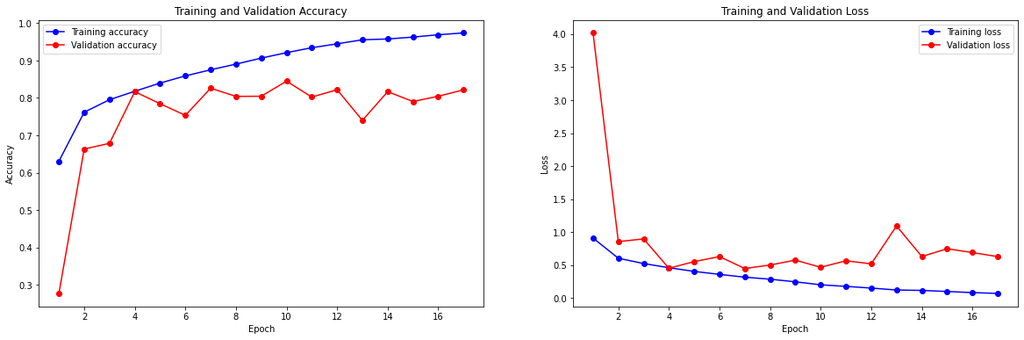

```python
plot(history)
```

```python
# Save and show validatin results
val_loss, val_acc = model.evaluate(val_dataset)

save_model_results(val_results_path, model_name, val_acc)

# Save test results for latter analysis

# model = keras.models.load_model("convnet_from_scratch.keras")
test_loss, test_acc = model.evaluate(test_dataset)
save_model_results(test_results_path, model_name, test_acc)

print(f"\nValidation accuracy: {val_acc:.3f}")
```

```
85/85 ━━━━━━━━━━━━━━━━━━━━ 3s 37ms/step - accuracy: 0.8239 - loss: 0.4569
47/47 ━━━━━━━━━━━━━━━━━━━━ 4s 88ms/step - accuracy: 0.8007 - loss: 0.5393
```

```
Validation accuracy: 0.826
```

### Discussion of Results

The results show a **slight improvement** over the previous model, though the difference is **minimal**. However, there is a noticeable increase in **resistance** to overfitting. Despite this improvement, the resistance to overfitting still appears to be **insufficient**. Therefore, we plan to explore other, **stronger regularization** techniques that could potentially enhance the results further.

## L2 Regularization + Batch Normalization + Data augmentation

In this updated model, we will **eliminate Dropout** to prevent potential **conflicts** with Batch Normalization and will **explore** the impact of incorporating **Data Augmentation** and **L2 Regularization**. These adjustments are aimed at enhancing the model's generalizability and reducing overfitting, focusing on creating a more robust and efficient learning process.

```python
inputs = keras.Input(shape=img_tensor_shape)

# Data Augmentation
data_augmentation = keras.Sequential([
    layers.RandomFlip("horizontal"),
    layers.RandomRotation(0.2),
    layers.RandomZoom(0.2),
], name="data_augmentation")

x = data_augmentation(inputs)  # Apply data augmentation to inputs

# Rescale images to [0, 1]
x = layers.Rescaling(1./255)(x)

# Convolutional block 1
x = layers.Conv2D(filters=32, kernel_size=3)(x)
x = layers.BatchNormalization()(x)
x = layers.Activation("relu")(x)
x = layers.MaxPooling2D(pool_size=2)(x)

# Convolutional block 2
x = layers.Conv2D(filters=64, kernel_size=3)(x)
x = layers.BatchNormalization()(x)
x = layers.Activation("relu")(x)
x = layers.MaxPooling2D(pool_size=2)(x)

# Convolutional block 3
x = layers.Conv2D(filters=128, kernel_size=3)(x)
x = layers.BatchNormalization()(x)
x = layers.Activation("relu")(x)
x = layers.MaxPooling2D(pool_size=2)(x)

# Convolutional block 4
x = layers.Conv2D(filters=128, kernel_size=3)(x)
x = layers.BatchNormalization()(x)
x = layers.Activation("relu")(x)
x = layers.MaxPooling2D(pool_size=2)(x)

# Convolutional block 5
x = layers.Conv2D(filters=256, kernel_size=3)(x)
x = layers.BatchNormalization()(x)
x = layers.Activation("relu")(x)
x = layers.MaxPooling2D(pool_size=2)(x)

# Convolutional block 6
x = layers.Conv2D(filters=256, kernel_size=3)(x)
x = layers.BatchNormalization()(x)
x = layers.Activation("relu")(x)
x = layers.Flatten()(x)  # Flatten the output to feed into a dense layer

# Dense block 1
x = layers.Dense(512, kernel_regularizer=l2(0.001))(x)
x = layers.BatchNormalization()(x)
x = layers.Activation("relu")(x)

# Dense block 2
x = layers.Dense(256, kernel_regularizer=l2(0.001))(x)
x = layers.BatchNormalization()(x)
x = layers.Activation("relu")(x)

# Dense block 3
x = layers.Dense(128, kernel_regularizer=l2(0.001))(x)
x = layers.BatchNormalization()(x)
x = layers.Activation("relu")(x)

# Output layer for 5 classes
outputs = layers.Dense(5, activation="softmax")(x)

model = keras.Model(inputs=inputs, outputs=outputs)
```

```python
# Compiling the model with sparse_categorical_crossentropy suitable for multi-class classification with integer labels
model.compile(optimizer='adam',
              loss='sparse_categorical_crossentropy',
              metrics=['accuracy'])

# Model summary to see the architecture
model.summary()
```

```
Model: "functional_2"
```

```
┏━━━━━━━━━━━━━━━━━━━━━━━━━━━━━━━━━┳━━━━━━━━━━━━━━━━━━━━━━━━━━━┳━━━━━━━━━━━━┓
┃ Layer (type)                    ┃ Output Shape              ┃    Param # ┃
┡━━━━━━━━━━━━━━━━━━━━━━━━━━━━━━━━━╇━━━━━━━━━━━━━━━━━━━━━━━━━━━╇━━━━━━━━━━━━┩
│ input_layer (InputLayer)        │ (None, 512, 512, 3)       │          0 │
├─────────────────────────────────┼───────────────────────────┼────────────┤
│ data_augmentation (Sequential)  │ (None, 512, 512, 3)       │          0 │
├─────────────────────────────────┼───────────────────────────┼────────────┤
│ rescaling (Rescaling)           │ (None, 512, 512, 3)       │          0 │
├─────────────────────────────────┼───────────────────────────┼────────────┤
│ conv2d (Conv2D)                 │ (None, 510, 510, 32)      │        896 │
├─────────────────────────────────┼───────────────────────────┼────────────┤
│ batch_normalization             │ (None, 510, 510, 32)      │        128 │
│ (BatchNormalization)            │                           │            │
├─────────────────────────────────┼───────────────────────────┼────────────┤
│ activation (Activation)         │ (None, 510, 510, 32)      │          0 │
├─────────────────────────────────┼───────────────────────────┼────────────┤
│ max_pooling2d (MaxPooling2D)    │ (None, 255, 255, 32)      │          0 │
├─────────────────────────────────┼───────────────────────────┼────────────┤
│ conv2d_1 (Conv2D)               │ (None, 253, 253, 64)      │     18,496 │
├─────────────────────────────────┼───────────────────────────┼────────────┤
│ batch_normalization_1           │ (None, 253, 253, 64)      │        256 │
│ (BatchNormalization)            │                           │            │
├─────────────────────────────────┼───────────────────────────┼────────────┤
│ activation_1 (Activation)       │ (None, 253, 253, 64)      │          0 │
├─────────────────────────────────┼───────────────────────────┼────────────┤
│ max_pooling2d_1 (MaxPooling2D)  │ (None, 126, 126, 64)      │          0 │
├─────────────────────────────────┼───────────────────────────┼────────────┤
│ conv2d_2 (Conv2D)               │ (None, 124, 124, 128)     │     73,856 │
├─────────────────────────────────┼───────────────────────────┼────────────┤
│ batch_normalization_2           │ (None, 124, 124, 128)     │        512 │
│ (BatchNormalization)            │                           │            │
├─────────────────────────────────┼───────────────────────────┼────────────┤
│ activation_2 (Activation)       │ (None, 124, 124, 128)     │          0 │
├─────────────────────────────────┼───────────────────────────┼────────────┤
│ max_pooling2d_2 (MaxPooling2D)  │ (None, 62, 62, 128)       │          0 │
├─────────────────────────────────┼───────────────────────────┼────────────┤
│ conv2d_3 (Conv2D)               │ (None, 60, 60, 128)       │    147,584 │
├─────────────────────────────────┼───────────────────────────┼────────────┤
│ batch_normalization_3           │ (None, 60, 60, 128)       │        512 │
│ (BatchNormalization)            │                           │            │
```

[output cut: 31 more lines]

```
├─────────────────────────────────┼───────────────────────────┼────────────┤
│ batch_normalization_7           │ (None, 256)               │      1,024 │
│ (BatchNormalization)            │                           │            │
├─────────────────────────────────┼───────────────────────────┼────────────┤
│ activation_7 (Activation)       │ (None, 256)               │          0 │
├─────────────────────────────────┼───────────────────────────┼────────────┤
│ dense_2 (Dense)                 │ (None, 128)               │     32,896 │
├─────────────────────────────────┼───────────────────────────┼────────────┤
│ batch_normalization_8           │ (None, 128)               │        512 │
│ (BatchNormalization)            │                           │            │
├─────────────────────────────────┼───────────────────────────┼────────────┤
│ activation_8 (Activation)       │ (None, 128)               │          0 │
├─────────────────────────────────┼───────────────────────────┼────────────┤
│ dense_3 (Dense)                 │ (None, 5)                 │        645 │
└─────────────────────────────────┴───────────────────────────┴────────────┘
```

```
 Total params: 20,172,869 (76.95 MB)
```

```
 Trainable params: 20,169,349 (76.94 MB)
```

```
 Non-trainable params: 3,520 (13.75 KB)
```

```python
model_name = 'custom_bn_l2_dAug_256'
```

```python
callbacks = [
    # ModelCheckpoint to save the model after every epoch if val_loss improves
    keras.callbacks.ModelCheckpoint(
        filepath="models/"+model_name+".keras",
        save_best_only=True,  # Only save a model if `val_loss` has improved
        monitor="val_loss"
    ),
    # EarlyStopping to stop training when `val_loss` is not improving
    keras.callbacks.EarlyStopping(
        monitor="val_loss",
        patience=20,
        restore_best_weights=True
    )
]

history = model.fit(
    train_dataset,
    epochs=200,
    validation_data=val_dataset,
    callbacks=callbacks
)
```

```
337/337 ━━━━━━━━━━━━━━━━━━━━ 120s 330ms/step - accuracy: 0.5288 - loss: 2.8305 - val_accuracy: 0.3909 - val_loss: 2.9130
337/337 ━━━━━━━━━━━━━━━━━━━━ 104s 308ms/step - accuracy: 0.6967 - loss: 1.4105 - val_accuracy: 0.7166 - val_loss: 1.1627
337/337 ━━━━━━━━━━━━━━━━━━━━ 103s 307ms/step - accuracy: 0.7267 - loss: 1.1176 - val_accuracy: 0.6614 - val_loss: 1.3143
337/337 ━━━━━━━━━━━━━━━━━━━━ 104s 308ms/step - accuracy: 0.7477 - loss: 0.9842 - val_accuracy: 0.6947 - val_loss: 1.1281
337/337 ━━━━━━━━━━━━━━━━━━━━ 103s 306ms/step - accuracy: 0.7622 - loss: 0.9065 - val_accuracy: 0.5067 - val_loss: 1.3944
337/337 ━━━━━━━━━━━━━━━━━━━━ 104s 309ms/step - accuracy: 0.7728 - loss: 0.8393 - val_accuracy: 0.7088 - val_loss: 0.9508
337/337 ━━━━━━━━━━━━━━━━━━━━ 103s 307ms/step - accuracy: 0.7757 - loss: 0.8219 - val_accuracy: 0.6858 - val_loss: 0.9870
337/337 ━━━━━━━━━━━━━━━━━━━━ 104s 308ms/step - accuracy: 0.7833 - loss: 0.7874 - val_accuracy: 0.7585 - val_loss: 0.8723
337/337 ━━━━━━━━━━━━━━━━━━━━ 104s 309ms/step - accuracy: 0.7995 - loss: 0.7641 - val_accuracy: 0.7715 - val_loss: 0.8603
337/337 ━━━━━━━━━━━━━━━━━━━━ 104s 308ms/step - accuracy: 0.8056 - loss: 0.7425 - val_accuracy: 0.7641 - val_loss: 0.8198
337/337 ━━━━━━━━━━━━━━━━━━━━ 104s 307ms/step - accuracy: 0.7957 - loss: 0.7390 - val_accuracy: 0.7530 - val_loss: 0.8897
337/337 ━━━━━━━━━━━━━━━━━━━━ 103s 307ms/step - accuracy: 0.8142 - loss: 0.7098 - val_accuracy: 0.7285 - val_loss: 0.9892
337/337 ━━━━━━━━━━━━━━━━━━━━ 104s 307ms/step - accuracy: 0.8188 - loss: 0.7146 - val_accuracy: 0.7385 - val_loss: 1.0235
337/337 ━━━━━━━━━━━━━━━━━━━━ 104s 308ms/step - accuracy: 0.8245 - loss: 0.7180 - val_accuracy: 0.7467 - val_loss: 0.9178
337/337 ━━━━━━━━━━━━━━━━━━━━ 104s 308ms/step - accuracy: 0.8367 - loss: 0.6650 - val_accuracy: 0.8123 - val_loss: 0.7072
337/337 ━━━━━━━━━━━━━━━━━━━━ 104s 307ms/step - accuracy: 0.8364 - loss: 0.6522 - val_accuracy: 0.7845 - val_loss: 0.7676
337/337 ━━━━━━━━━━━━━━━━━━━━ 104s 307ms/step - accuracy: 0.8353 - loss: 0.6600 - val_accuracy: 0.6843 - val_loss: 1.1601
337/337 ━━━━━━━━━━━━━━━━━━━━ 104s 308ms/step - accuracy: 0.8441 - loss: 0.6148 - val_accuracy: 0.7993 - val_loss: 0.6845
337/337 ━━━━━━━━━━━━━━━━━━━━ 104s 309ms/step - accuracy: 0.8521 - loss: 0.5946 - val_accuracy: 0.8338 - val_loss: 0.6222
337/337 ━━━━━━━━━━━━━━━━━━━━ 104s 307ms/step - accuracy: 0.8600 - loss: 0.5463 - val_accuracy: 0.8346 - val_loss: 0.6776
337/337 ━━━━━━━━━━━━━━━━━━━━ 104s 308ms/step - accuracy: 0.8626 - loss: 0.5625 - val_accuracy: 0.8780 - val_loss: 0.5219
337/337 ━━━━━━━━━━━━━━━━━━━━ 104s 307ms/step - accuracy: 0.8643 - loss: 0.5482 - val_accuracy: 0.8602 - val_loss: 0.5516
337/337 ━━━━━━━━━━━━━━━━━━━━ 104s 307ms/step - accuracy: 0.8704 - loss: 0.5089 - val_accuracy: 0.8583 - val_loss: 0.5451
337/337 ━━━━━━━━━━━━━━━━━━━━ 104s 307ms/step - accuracy: 0.8702 - loss: 0.5140 - val_accuracy: 0.8535 - val_loss: 0.5685
337/337 ━━━━━━━━━━━━━━━━━━━━ 104s 308ms/step - accuracy: 0.8728 - loss: 0.5043 - val_accuracy: 0.8813 - val_loss: 0.4654
337/337 ━━━━━━━━━━━━━━━━━━━━ 104s 307ms/step - accuracy: 0.8772 - loss: 0.4923 - val_accuracy: 0.8260 - val_loss: 0.6231
337/337 ━━━━━━━━━━━━━━━━━━━━ 104s 308ms/step - accuracy: 0.8883 - loss: 0.4289 - val_accuracy: 0.8854 - val_loss: 0.4163
337/337 ━━━━━━━━━━━━━━━━━━━━ 104s 307ms/step - accuracy: 0.8764 - loss: 0.4533 - val_accuracy: 0.8565 - val_loss: 0.4915
337/337 ━━━━━━━━━━━━━━━━━━━━ 104s 308ms/step - accuracy: 0.8836 - loss: 0.4281 - val_accuracy: 0.9024 - val_loss: 0.3917
337/337 ━━━━━━━━━━━━━━━━━━━━ 104s 307ms/step - accuracy: 0.8874 - loss: 0.4161 - val_accuracy: 0.8861 - val_loss: 0.4113
337/337 ━━━━━━━━━━━━━━━━━━━━ 104s 307ms/step - accuracy: 0.8964 - loss: 0.3778 - val_accuracy: 0.8824 - val_loss: 0.4097
337/337 ━━━━━━━━━━━━━━━━━━━━ 104s 308ms/step - accuracy: 0.8933 - loss: 0.3812 - val_accuracy: 0.8999 - val_loss: 0.3712
337/337 ━━━━━━━━━━━━━━━━━━━━ 104s 308ms/step - accuracy: 0.8983 - loss: 0.3715 - val_accuracy: 0.8950 - val_loss: 0.3692
337/337 ━━━━━━━━━━━━━━━━━━━━ 104s 308ms/step - accuracy: 0.8980 - loss: 0.3692 - val_accuracy: 0.9125 - val_loss: 0.3163
337/337 ━━━━━━━━━━━━━━━━━━━━ 104s 307ms/step - accuracy: 0.8997 - loss: 0.3498 - val_accuracy: 0.9073 - val_loss: 0.3377
337/337 ━━━━━━━━━━━━━━━━━━━━ 104s 308ms/step - accuracy: 0.9022 - loss: 0.3547 - val_accuracy: 0.8194 - val_loss: 0.5323
337/337 ━━━━━━━━━━━━━━━━━━━━ 104s 307ms/step - accuracy: 0.9050 - loss: 0.3423 - val_accuracy: 0.8858 - val_loss: 0.3935
337/337 ━━━━━━━━━━━━━━━━━━━━ 104s 307ms/step - accuracy: 0.9176 - loss: 0.3103 - val_accuracy: 0.9039 - val_loss: 0.3409
337/337 ━━━━━━━━━━━━━━━━━━━━ 103s 307ms/step - accuracy: 0.9075 - loss: 0.3339 - val_accuracy: 0.8969 - val_loss: 0.3643
337/337 ━━━━━━━━━━━━━━━━━━━━ 104s 307ms/step - accuracy: 0.9152 - loss: 0.3150 - val_accuracy: 0.8858 - val_loss: 0.3852
```

[output cut: 22 more lines]

```
337/337 ━━━━━━━━━━━━━━━━━━━━ 103s 307ms/step - accuracy: 0.9394 - loss: 0.2310 - val_accuracy: 0.9158 - val_loss: 0.3087
337/337 ━━━━━━━━━━━━━━━━━━━━ 104s 307ms/step - accuracy: 0.9393 - loss: 0.2416 - val_accuracy: 0.9151 - val_loss: 0.3115
337/337 ━━━━━━━━━━━━━━━━━━━━ 104s 307ms/step - accuracy: 0.9423 - loss: 0.2250 - val_accuracy: 0.9128 - val_loss: 0.3132
337/337 ━━━━━━━━━━━━━━━━━━━━ 103s 306ms/step - accuracy: 0.9387 - loss: 0.2330 - val_accuracy: 0.9254 - val_loss: 0.2774
337/337 ━━━━━━━━━━━━━━━━━━━━ 103s 307ms/step - accuracy: 0.9369 - loss: 0.2382 - val_accuracy: 0.9084 - val_loss: 0.3225
337/337 ━━━━━━━━━━━━━━━━━━━━ 103s 307ms/step - accuracy: 0.9443 - loss: 0.2253 - val_accuracy: 0.9221 - val_loss: 0.2922
337/337 ━━━━━━━━━━━━━━━━━━━━ 104s 307ms/step - accuracy: 0.9433 - loss: 0.2188 - val_accuracy: 0.9158 - val_loss: 0.3197
337/337 ━━━━━━━━━━━━━━━━━━━━ 104s 307ms/step - accuracy: 0.9505 - loss: 0.2086 - val_accuracy: 0.9050 - val_loss: 0.3614
337/337 ━━━━━━━━━━━━━━━━━━━━ 104s 307ms/step - accuracy: 0.9411 - loss: 0.2247 - val_accuracy: 0.9254 - val_loss: 0.2843
337/337 ━━━━━━━━━━━━━━━━━━━━ 103s 306ms/step - accuracy: 0.9413 - loss: 0.2248 - val_accuracy: 0.9084 - val_loss: 0.3566
337/337 ━━━━━━━━━━━━━━━━━━━━ 104s 307ms/step - accuracy: 0.9423 - loss: 0.2245 - val_accuracy: 0.9347 - val_loss: 0.2659
337/337 ━━━━━━━━━━━━━━━━━━━━ 103s 307ms/step - accuracy: 0.9518 - loss: 0.2006 - val_accuracy: 0.9021 - val_loss: 0.3634
337/337 ━━━━━━━━━━━━━━━━━━━━ 103s 306ms/step - accuracy: 0.9436 - loss: 0.2062 - val_accuracy: 0.9310 - val_loss: 0.2657
337/337 ━━━━━━━━━━━━━━━━━━━━ 103s 307ms/step - accuracy: 0.9505 - loss: 0.2009 - val_accuracy: 0.9258 - val_loss: 0.2690
337/337 ━━━━━━━━━━━━━━━━━━━━ 104s 307ms/step - accuracy: 0.9482 - loss: 0.2059 - val_accuracy: 0.9017 - val_loss: 0.3921
```

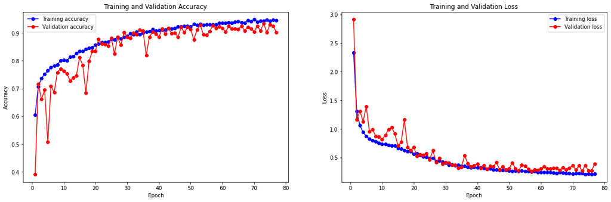

```python
plot(history)
```

```python
# Save and show validatin results
val_loss, val_acc = model.evaluate(val_dataset)

save_model_results(val_results_path, model_name, val_acc)

# Save test results for latter analysis

# model = keras.models.load_model("convnet_from_scratch.keras")
test_loss, test_acc = model.evaluate(test_dataset)
save_model_results(test_results_path, model_name, test_acc)

print(f"\nValidation accuracy: {val_acc:.3f}")
```

```
85/85 ━━━━━━━━━━━━━━━━━━━━ 6s 67ms/step - accuracy: 0.9229 - loss: 0.2901
47/47 ━━━━━━━━━━━━━━━━━━━━ 5s 96ms/step - accuracy: 0.9181 - loss: 0.2896
```

```
Validation accuracy: 0.927
```

### Discussion of Results

The results show a **significant improvement** over previous iterations, achieving a notably high accuracy of **0.927**. Additionally, there's a **remarkably** enhanced **resistance to overfitting** compared to earlier models. However, there comes a point where the model **ceases** to improve, indicating a potential ceiling with the current architecture. To address this, we plan to explore the use of **more complex** and **deeper** models, including the incorporation of **residual connections**.

## Custom ResNet + bn + l2

In this scenario, we are testing a **deeper** model with **residual connections**. Unfortunately, the model's size **exceeds** the available VRAM on the GPU, leading to **memory errors**. To address this issue, we have decided to **reduce** the **image size**. We have chosen a resolution of **256x256** pixels, which represents a **middle ground** between the two most **common** resolutions: **64x64** and **512x512**. This compromise allows us to leverage the benefits of a more complex model with residual connections for better feature propagation and error gradient flow, without exceeding the memory limitations of our hardware. This adjustment aims to maintain a balance between model complexity and computational feasibility, potentially enhancing the model's performance without incurring memory overflow errors.

```python
img_size = 256
image_size = (img_size, img_size)
img_tensor_shape = (img_size, img_size, 3)
batch_size = 32

train_dataset = image_dataset_from_directory(
    '../data/new_data/train',
    image_size = image_size,
    batch_size = batch_size)
test_dataset = image_dataset_from_directory(
    '../data/new_data/test',
    image_size = image_size,
    batch_size=batch_size)
val_dataset = image_dataset_from_directory(
    '../data/new_data/validation',
    image_size = image_size,
    batch_size=batch_size)
```

```
Found 10778 files belonging to 5 classes.
Found 1497 files belonging to 5 classes.
Found 2696 files belonging to 5 classes.
```

```python
def residual_block(x, filters, pooling=False):
    residual = x
    # First convolution without activation, followed by BatchNormalization and ReLU
    x = layers.Conv2D(filters, 3, padding="same")(x)
    x = layers.BatchNormalization()(x)
    x = layers.Activation("relu")(x)

    # Second convolution without activation, followed by BatchNormalization and ReLU
    x = layers.Conv2D(filters, 3, padding="same")(x)
    x = layers.BatchNormalization()(x)
    x = layers.Activation("relu")(x)

    if pooling:  # if pooling, we use strides in the residual connection
        x = layers.MaxPooling2D(2, padding="same")(x)
        residual = layers.Conv2D(filters, 1, strides=2)(residual)
    elif filters != residual.shape[-1]:
        # Adjusting the residual path's filter size if necessary
        residual = layers.Conv2D(filters, 1)(residual)
        residual = layers.BatchNormalization()(residual)  # Adding BatchNormalization here as well

    x = layers.add([x, residual])
    return x
```

```python
inputs = keras.Input(shape=img_tensor_shape)

# Data Augmentation
data_augmentation = keras.Sequential([
    layers.RandomFlip("horizontal"),
    layers.RandomRotation(0.2),
    layers.RandomZoom(0.2),
], name="data_augmentation")

x = data_augmentation(inputs)  # Apply data augmentation to inputs

# Rescale images to [0, 1]
x = layers.Rescaling(1./255)(x)

x = residual_block(x, filters=32, pooling=False)
x = residual_block(x, filters=32, pooling=True)

x = residual_block(x, filters=64, pooling=False)
x = residual_block(x, filters=64, pooling=True)

x = residual_block(x, filters=128, pooling=False)
x = residual_block(x, filters=128, pooling=False)
x = residual_block(x, filters=128, pooling=True)

x = residual_block(x, filters=256, pooling=False)
x = residual_block(x, filters=256, pooling=False)
x = residual_block(x, filters=256, pooling=False)
x = residual_block(x, filters=256, pooling=True)

x = residual_block(x, filters=512, pooling=False)
x = residual_block(x, filters=512, pooling=False)
x = residual_block(x, filters=512, pooling=False)
x = residual_block(x, filters=512, pooling=False)
x = residual_block(x, filters=512, pooling=False)

# The last block doesn’t need a max pooling layer,
# since we will apply global average pooling right after it.
x = layers.GlobalAveragePooling2D()(x)

# Dense block 1
x = layers.Dense(512, kernel_regularizer=l2(0.001))(x)
x = layers.BatchNormalization()(x)
x = layers.Activation("relu")(x)

# Dense block 2
x = layers.Dense(256, kernel_regularizer=l2(0.001))(x)
x = layers.BatchNormalization()(x)
x = layers.Activation("relu")(x)

# Dense block 3
x = layers.Dense(128, kernel_regularizer=l2(0.001))(x)
x = layers.BatchNormalization()(x)
x = layers.Activation("relu")(x)

# Output layer for 5 classes
outputs = layers.Dense(5, activation="softmax")(x)

model = keras.Model(inputs=inputs, outputs=outputs)
```

```python
# Compiling the model with sparse_categorical_crossentropy suitable for multi-class classification with integer labels
model.compile(optimizer='adam',
              loss='sparse_categorical_crossentropy',
              metrics=['accuracy'])

# Model summary to see the architecture
model.summary()
```

```
Model: "functional_2"
```

```
┏━━━━━━━━━━━━━━━━━━━━━┳━━━━━━━━━━━━━━━━━━━┳━━━━━━━━━┳━━━━━━━━━━━━━━━━━━━━━━┓
┃ Layer (type)        ┃ Output Shape      ┃ Param # ┃ Connected to         ┃
┡━━━━━━━━━━━━━━━━━━━━━╇━━━━━━━━━━━━━━━━━━━╇━━━━━━━━━╇━━━━━━━━━━━━━━━━━━━━━━┩
│ input_layer         │ (None, 256, 256,  │       0 │ -                    │
│ (InputLayer)        │ 3)                │         │                      │
├─────────────────────┼───────────────────┼─────────┼──────────────────────┤
│ data_augmentation   │ (None, 256, 256,  │       0 │ input_layer[0][0]    │
│ (Sequential)        │ 3)                │         │                      │
├─────────────────────┼───────────────────┼─────────┼──────────────────────┤
│ rescaling           │ (None, 256, 256,  │       0 │ data_augmentation[0… │
│ (Rescaling)         │ 3)                │         │                      │
├─────────────────────┼───────────────────┼─────────┼──────────────────────┤
│ conv2d (Conv2D)     │ (None, 256, 256,  │     896 │ rescaling[0][0]      │
│                     │ 32)               │         │                      │
├─────────────────────┼───────────────────┼─────────┼──────────────────────┤
│ batch_normalization │ (None, 256, 256,  │     128 │ conv2d[0][0]         │
│ (BatchNormalizatio… │ 32)               │         │                      │
├─────────────────────┼───────────────────┼─────────┼──────────────────────┤
│ activation          │ (None, 256, 256,  │       0 │ batch_normalization… │
│ (Activation)        │ 32)               │         │                      │
├─────────────────────┼───────────────────┼─────────┼──────────────────────┤
│ conv2d_1 (Conv2D)   │ (None, 256, 256,  │   9,248 │ activation[0][0]     │
│                     │ 32)               │         │                      │
├─────────────────────┼───────────────────┼─────────┼──────────────────────┤
│ batch_normalizatio… │ (None, 256, 256,  │     128 │ conv2d_1[0][0]       │
│ (BatchNormalizatio… │ 32)               │         │                      │
├─────────────────────┼───────────────────┼─────────┼──────────────────────┤
│ conv2d_2 (Conv2D)   │ (None, 256, 256,  │     128 │ rescaling[0][0]      │
│                     │ 32)               │         │                      │
├─────────────────────┼───────────────────┼─────────┼──────────────────────┤
│ activation_1        │ (None, 256, 256,  │       0 │ batch_normalization… │
│ (Activation)        │ 32)               │         │                      │
├─────────────────────┼───────────────────┼─────────┼──────────────────────┤
│ batch_normalizatio… │ (None, 256, 256,  │     128 │ conv2d_2[0][0]       │
│ (BatchNormalizatio… │ 32)               │         │                      │
├─────────────────────┼───────────────────┼─────────┼──────────────────────┤
│ add (Add)           │ (None, 256, 256,  │       0 │ activation_1[0][0],  │
│                     │ 32)               │         │ batch_normalization… │
├─────────────────────┼───────────────────┼─────────┼──────────────────────┤
│ conv2d_3 (Conv2D)   │ (None, 256, 256,  │   9,248 │ add[0][0]            │
```

[output cut: 376 more lines]

```
│ (BatchNormalizatio… │                   │         │                      │
├─────────────────────┼───────────────────┼─────────┼──────────────────────┤
│ activation_33       │ (None, 256)       │       0 │ batch_normalization… │
│ (Activation)        │                   │         │                      │
├─────────────────────┼───────────────────┼─────────┼──────────────────────┤
│ dense_2 (Dense)     │ (None, 128)       │  32,896 │ activation_33[0][0]  │
├─────────────────────┼───────────────────┼─────────┼──────────────────────┤
│ batch_normalizatio… │ (None, 128)       │     512 │ dense_2[0][0]        │
│ (BatchNormalizatio… │                   │         │                      │
├─────────────────────┼───────────────────┼─────────┼──────────────────────┤
│ activation_34       │ (None, 128)       │       0 │ batch_normalization… │
│ (Activation)        │                   │         │                      │
├─────────────────────┼───────────────────┼─────────┼──────────────────────┤
│ dense_3 (Dense)     │ (None, 5)         │     645 │ activation_34[0][0]  │
└─────────────────────┴───────────────────┴─────────┴──────────────────────┘
```

```
 Total params: 28,544,901 (108.89 MB)
```

```
 Trainable params: 28,524,485 (108.81 MB)
```

```
 Non-trainable params: 20,416 (79.75 KB)
```

```python
model_name = 'custom_deepResNet_bn_l2'
```

```python
callbacks = [
    # ModelCheckpoint to save the model after every epoch if val_loss improves
    keras.callbacks.ModelCheckpoint(
        filepath="models/"+model_name+".keras",
        save_best_only=True,  # Only save a model if `val_loss` has improved
        monitor="val_loss"
    ),
    # EarlyStopping to stop training when `val_loss` is not improving
    keras.callbacks.EarlyStopping(
        monitor="val_loss",
        patience=30,
        restore_best_weights=True
    )
]

history = model.fit(
    train_dataset,
    epochs=200,
    validation_data=val_dataset,
    callbacks=callbacks
)
```

```
337/337 ━━━━━━━━━━━━━━━━━━━━ 189s 511ms/step - accuracy: 0.4036 - loss: 2.3564 - val_accuracy: 0.3846 - val_loss: 2.4538
337/337 ━━━━━━━━━━━━━━━━━━━━ 163s 484ms/step - accuracy: 0.5308 - loss: 1.6161 - val_accuracy: 0.5174 - val_loss: 1.5849
337/337 ━━━━━━━━━━━━━━━━━━━━ 162s 481ms/step - accuracy: 0.5951 - loss: 1.2200 - val_accuracy: 0.5252 - val_loss: 1.5835
337/337 ━━━━━━━━━━━━━━━━━━━━ 162s 482ms/step - accuracy: 0.6138 - loss: 1.0538 - val_accuracy: 0.5119 - val_loss: 1.3714
337/337 ━━━━━━━━━━━━━━━━━━━━ 163s 482ms/step - accuracy: 0.6531 - loss: 0.9244 - val_accuracy: 0.7211 - val_loss: 0.7876
337/337 ━━━━━━━━━━━━━━━━━━━━ 162s 480ms/step - accuracy: 0.6698 - loss: 0.8724 - val_accuracy: 0.6962 - val_loss: 0.7977
337/337 ━━━━━━━━━━━━━━━━━━━━ 162s 480ms/step - accuracy: 0.7041 - loss: 0.7963 - val_accuracy: 0.6020 - val_loss: 1.0305
337/337 ━━━━━━━━━━━━━━━━━━━━ 162s 480ms/step - accuracy: 0.7177 - loss: 0.7440 - val_accuracy: 0.6209 - val_loss: 1.1119
337/337 ━━━━━━━━━━━━━━━━━━━━ 162s 481ms/step - accuracy: 0.7378 - loss: 0.6900 - val_accuracy: 0.6428 - val_loss: 1.0930
337/337 ━━━━━━━━━━━━━━━━━━━━ 162s 481ms/step - accuracy: 0.7511 - loss: 0.6538 - val_accuracy: 0.7533 - val_loss: 0.6875
337/337 ━━━━━━━━━━━━━━━━━━━━ 162s 480ms/step - accuracy: 0.7627 - loss: 0.6294 - val_accuracy: 0.7044 - val_loss: 0.7919
337/337 ━━━━━━━━━━━━━━━━━━━━ 162s 480ms/step - accuracy: 0.7727 - loss: 0.6106 - val_accuracy: 0.5634 - val_loss: 1.4231
337/337 ━━━━━━━━━━━━━━━━━━━━ 162s 480ms/step - accuracy: 0.7794 - loss: 0.5968 - val_accuracy: 0.7055 - val_loss: 0.9107
337/337 ━━━━━━━━━━━━━━━━━━━━ 162s 481ms/step - accuracy: 0.7874 - loss: 0.5849 - val_accuracy: 0.6929 - val_loss: 0.8008
337/337 ━━━━━━━━━━━━━━━━━━━━ 162s 481ms/step - accuracy: 0.8011 - loss: 0.5454 - val_accuracy: 0.6324 - val_loss: 0.9477
337/337 ━━━━━━━━━━━━━━━━━━━━ 162s 482ms/step - accuracy: 0.8028 - loss: 0.5357 - val_accuracy: 0.7522 - val_loss: 0.6698
337/337 ━━━━━━━━━━━━━━━━━━━━ 162s 481ms/step - accuracy: 0.8045 - loss: 0.5325 - val_accuracy: 0.6999 - val_loss: 0.7314
337/337 ━━━━━━━━━━━━━━━━━━━━ 162s 481ms/step - accuracy: 0.8198 - loss: 0.5064 - val_accuracy: 0.7226 - val_loss: 0.8930
337/337 ━━━━━━━━━━━━━━━━━━━━ 162s 482ms/step - accuracy: 0.8145 - loss: 0.5183 - val_accuracy: 0.8297 - val_loss: 0.5017
337/337 ━━━━━━━━━━━━━━━━━━━━ 162s 480ms/step - accuracy: 0.8309 - loss: 0.4678 - val_accuracy: 0.7014 - val_loss: 0.8728
337/337 ━━━━━━━━━━━━━━━━━━━━ 162s 480ms/step - accuracy: 0.8365 - loss: 0.4624 - val_accuracy: 0.7040 - val_loss: 0.7944
337/337 ━━━━━━━━━━━━━━━━━━━━ 162s 480ms/step - accuracy: 0.8263 - loss: 0.4770 - val_accuracy: 0.7819 - val_loss: 0.6124
337/337 ━━━━━━━━━━━━━━━━━━━━ 162s 480ms/step - accuracy: 0.8423 - loss: 0.4464 - val_accuracy: 0.7774 - val_loss: 0.6130
337/337 ━━━━━━━━━━━━━━━━━━━━ 162s 481ms/step - accuracy: 0.8409 - loss: 0.4554 - val_accuracy: 0.7122 - val_loss: 0.9535
337/337 ━━━━━━━━━━━━━━━━━━━━ 162s 481ms/step - accuracy: 0.8465 - loss: 0.4324 - val_accuracy: 0.7003 - val_loss: 0.7469
337/337 ━━━━━━━━━━━━━━━━━━━━ 162s 480ms/step - accuracy: 0.8477 - loss: 0.4209 - val_accuracy: 0.7912 - val_loss: 0.5947
337/337 ━━━━━━━━━━━━━━━━━━━━ 162s 481ms/step - accuracy: 0.8540 - loss: 0.4127 - val_accuracy: 0.7789 - val_loss: 0.6440
337/337 ━━━━━━━━━━━━━━━━━━━━ 162s 481ms/step - accuracy: 0.8563 - loss: 0.4053 - val_accuracy: 0.7170 - val_loss: 0.8593
337/337 ━━━━━━━━━━━━━━━━━━━━ 162s 482ms/step - accuracy: 0.8594 - loss: 0.3868 - val_accuracy: 0.8635 - val_loss: 0.4075
337/337 ━━━━━━━━━━━━━━━━━━━━ 162s 482ms/step - accuracy: 0.8673 - loss: 0.3915 - val_accuracy: 0.8724 - val_loss: 0.3697
337/337 ━━━━━━━━━━━━━━━━━━━━ 162s 481ms/step - accuracy: 0.8666 - loss: 0.3789 - val_accuracy: 0.8208 - val_loss: 0.5225
337/337 ━━━━━━━━━━━━━━━━━━━━ 162s 480ms/step - accuracy: 0.8668 - loss: 0.3807 - val_accuracy: 0.7912 - val_loss: 0.5368
337/337 ━━━━━━━━━━━━━━━━━━━━ 162s 480ms/step - accuracy: 0.8658 - loss: 0.3617 - val_accuracy: 0.8290 - val_loss: 0.4955
337/337 ━━━━━━━━━━━━━━━━━━━━ 162s 481ms/step - accuracy: 0.8745 - loss: 0.3526 - val_accuracy: 0.7511 - val_loss: 0.8054
337/337 ━━━━━━━━━━━━━━━━━━━━ 162s 480ms/step - accuracy: 0.8716 - loss: 0.3583 - val_accuracy: 0.8268 - val_loss: 0.4638
337/337 ━━━━━━━━━━━━━━━━━━━━ 162s 480ms/step - accuracy: 0.8771 - loss: 0.3531 - val_accuracy: 0.8468 - val_loss: 0.4724
337/337 ━━━━━━━━━━━━━━━━━━━━ 162s 480ms/step - accuracy: 0.8862 - loss: 0.3244 - val_accuracy: 0.6684 - val_loss: 0.7671
337/337 ━━━━━━━━━━━━━━━━━━━━ 163s 482ms/step - accuracy: 0.8815 - loss: 0.3241 - val_accuracy: 0.8802 - val_loss: 0.3458
337/337 ━━━━━━━━━━━━━━━━━━━━ 162s 480ms/step - accuracy: 0.8884 - loss: 0.3197 - val_accuracy: 0.7953 - val_loss: 0.5313
337/337 ━━━━━━━━━━━━━━━━━━━━ 162s 480ms/step - accuracy: 0.8871 - loss: 0.3079 - val_accuracy: 0.8338 - val_loss: 0.5601
```

[output cut: 145 more lines]

```
337/337 ━━━━━━━━━━━━━━━━━━━━ 161s 478ms/step - accuracy: 0.9806 - loss: 0.0633 - val_accuracy: 0.9392 - val_loss: 0.2809
337/337 ━━━━━━━━━━━━━━━━━━━━ 161s 477ms/step - accuracy: 0.9827 - loss: 0.0611 - val_accuracy: 0.9392 - val_loss: 0.2234
337/337 ━━━━━━━━━━━━━━━━━━━━ 161s 479ms/step - accuracy: 0.9846 - loss: 0.0574 - val_accuracy: 0.9477 - val_loss: 0.1803
337/337 ━━━━━━━━━━━━━━━━━━━━ 161s 478ms/step - accuracy: 0.9821 - loss: 0.0644 - val_accuracy: 0.9414 - val_loss: 0.2073
337/337 ━━━━━━━━━━━━━━━━━━━━ 161s 478ms/step - accuracy: 0.9834 - loss: 0.0494 - val_accuracy: 0.9458 - val_loss: 0.2222
337/337 ━━━━━━━━━━━━━━━━━━━━ 161s 478ms/step - accuracy: 0.9779 - loss: 0.0776 - val_accuracy: 0.9336 - val_loss: 0.2220
337/337 ━━━━━━━━━━━━━━━━━━━━ 161s 478ms/step - accuracy: 0.9840 - loss: 0.0571 - val_accuracy: 0.9251 - val_loss: 0.3256
337/337 ━━━━━━━━━━━━━━━━━━━━ 161s 478ms/step - accuracy: 0.9813 - loss: 0.0583 - val_accuracy: 0.9340 - val_loss: 0.2728
337/337 ━━━━━━━━━━━━━━━━━━━━ 161s 477ms/step - accuracy: 0.9824 - loss: 0.0560 - val_accuracy: 0.9351 - val_loss: 0.3101
337/337 ━━━━━━━━━━━━━━━━━━━━ 161s 478ms/step - accuracy: 0.9823 - loss: 0.0611 - val_accuracy: 0.9470 - val_loss: 0.1959
337/337 ━━━━━━━━━━━━━━━━━━━━ 161s 478ms/step - accuracy: 0.9846 - loss: 0.0548 - val_accuracy: 0.9054 - val_loss: 0.3674
337/337 ━━━━━━━━━━━━━━━━━━━━ 161s 478ms/step - accuracy: 0.9818 - loss: 0.0610 - val_accuracy: 0.9336 - val_loss: 0.2606
337/337 ━━━━━━━━━━━━━━━━━━━━ 161s 477ms/step - accuracy: 0.9852 - loss: 0.0494 - val_accuracy: 0.9455 - val_loss: 0.1808
337/337 ━━━━━━━━━━━━━━━━━━━━ 161s 478ms/step - accuracy: 0.9844 - loss: 0.0553 - val_accuracy: 0.9269 - val_loss: 0.2844
337/337 ━━━━━━━━━━━━━━━━━━━━ 161s 477ms/step - accuracy: 0.9848 - loss: 0.0508 - val_accuracy: 0.8928 - val_loss: 0.4578
```

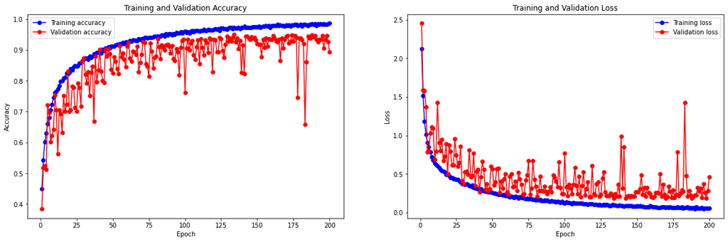

```python
plot(history)
```

```python
# Save and show validatin results
val_loss, val_acc = model.evaluate(val_dataset)

save_model_results(val_results_path, model_name, val_acc)

# Save test results for latter analysis

# model = keras.models.load_model("convnet_from_scratch.keras")
test_loss, test_acc = model.evaluate(test_dataset)
save_model_results(test_results_path, model_name, test_acc)

print(f"\nValidation accuracy: {val_acc:.3f}")
```

```
85/85 ━━━━━━━━━━━━━━━━━━━━ 9s 105ms/step - accuracy: 0.9489 - loss: 0.1819
47/47 ━━━━━━━━━━━━━━━━━━━━ 7s 139ms/step - accuracy: 0.9537 - loss: 0.1465
```

```
Validation accuracy: 0.948
```

### Discussion of Results

Despite a more **unstable** training phase, this model **outperforms** all previous iterations in terms of validation set accuracy, achieving a **94.7%** success rate.

## Custom Inception Model + Batch Normalization + L2 regularization

Finally, we aimed to explore the potential of **wide** Convolutional Neural Networks by testing **customized Inception** models. Unfortunately, after several attempts and configurations, the **available VRAM** posed significant **limitations** to our training efforts. We attempted **various strategies** to mitigate these issues, including **reducing** the **batch size**, lowering the **image resolution**, and repeatedly downsizing the **model itself**. Despite these adjustments, as noted below, we continued to encounter **memory-related errors**. Given that the models we have developed so far deliver **very satisfactory** results, we have decided to cease efforts in utilizing custom Inception models. This decision leaves the exploration of Inception-based architectures for **fine-tuning** with **pre-trained** models where the computational overhead might be more manageable.

```python
img_size = 128
image_size = (img_size, img_size)
img_tensor_shape = (img_size, img_size, 3)
batch_size = 16
```

```python
train_dataset = image_dataset_from_directory(
    '../data/new_data/train',
    image_size = image_size,
    batch_size = batch_size)
test_dataset = image_dataset_from_directory(
    '../data/new_data/test',
    image_size = image_size,
    batch_size=batch_size)
val_dataset = image_dataset_from_directory(
    '../data/new_data/validation',
    image_size = image_size,
    batch_size=batch_size)
```

```
Found 10778 files belonging to 5 classes.
Found 1497 files belonging to 5 classes.
Found 2696 files belonging to 5 classes.
```

```python
def inception_module(x, filters_1x1, filters_3x3_reduce, filters_3x3, filters_5x5_reduce,
                           filters_5x5, filters_pool_proj, name=None):
    # 1x1 convolution followed by batch normalization
    conv_1x1 = layers.Conv2D(filters_1x1, (1, 1), padding='same', activation='relu')(x)
    conv_1x1 = layers.BatchNormalization()(conv_1x1)

    # 1x1 followed by 3x3 convolution, each followed by batch normalization
    pre_conv_3x3 = layers.Conv2D(filters_3x3_reduce, (1, 1), padding='same', activation='relu')(x)
    pre_conv_3x3 = layers.BatchNormalization()(pre_conv_3x3)
    conv_3x3 = layers.Conv2D(filters_3x3, (3, 3), padding='same', activation='relu')(pre_conv_3x3)
    conv_3x3 = layers.BatchNormalization()(conv_3x3)

    # 1x1 followed by 5x5 convolution, each followed by batch normalization
    pre_conv_5x5 = layers.Conv2D(filters_5x5_reduce, (1, 1), padding='same', activation='relu')(x)
    pre_conv_5x5 = layers.BatchNormalization()(pre_conv_5x5)
    conv_5x5 = layers.Conv2D(filters_5x5, (5, 5), padding='same', activation='relu')(pre_conv_5x5)
    conv_5x5 = layers.BatchNormalization()(conv_5x5)

    # Max pooling followed by 1x1 convolution, then batch normalization
    pool_proj = layers.MaxPooling2D((3, 3), strides=(1, 1), padding='same')(x)
    pool_proj = layers.Conv2D(filters_pool_proj, (1, 1), padding='same', activation='relu')(pool_proj)
    pool_proj = layers.BatchNormalization()(pool_proj)

    # Concatenate all the convolutions
    output = layers.concatenate([conv_1x1, conv_3x3, conv_5x5, pool_proj], axis=-1, name=name)

    return output
```

```python
inputs = keras.Input(shape=img_tensor_shape)

# Data Augmentation
data_augmentation = keras.Sequential([
    layers.RandomFlip("horizontal"),
    layers.RandomRotation(0.2),
    layers.RandomZoom(0.2),
], name="data_augmentation")

x = data_augmentation(inputs)  # Apply data augmentation to inputs

# Rescale images to [0, 1]
x = layers.Rescaling(1./255)(x)

x = inception_module(x, 64, 16, 64, 16, 64, 64, name='inception_1')

x = inception_module(x, 128, 32, 128, 32, 128, 128, name='inception_2')
x = inception_module(x, 128, 32, 128, 32, 128, 128, name='inception_3')

# x = inception_module(x, 256, 32, 256, 32, 256, 256, name='inception_4')
x = inception_module(x, 256, 32, 256, 32, 256, 256, name='inception_5')
x = inception_module(x, 256, 32, 256, 32, 256, 256, name='inception_6')

# x = inception_module(x, 512, 32, 512, 32, 512, 512, name='inception_7')
# x = inception_module(x, 512, 32, 512, 32, 512, 512, name='inception_9')
# x = inception_module(x, 512, 32, 512, 32, 512, 512, name='inception_10')
# x = inception_module(x, 512, 32, 512, 32, 512, 512, name='inception_11')

# The last block doesn’t need a max pooling layer,
# since we will apply global average pooling right after it.
x = layers.GlobalAveragePooling2D()(x)

# Dense block 1
x = layers.Dense(512, kernel_regularizer=l2(0.001))(x)
x = layers.BatchNormalization()(x)
x = layers.Activation("relu")(x)

# Dense block 2
x = layers.Dense(256, kernel_regularizer=l2(0.001))(x)
x = layers.BatchNormalization()(x)
x = layers.Activation("relu")(x)

# Dense block 3
x = layers.Dense(128, kernel_regularizer=l2(0.001))(x)
x = layers.BatchNormalization()(x)
x = layers.Activation("relu")(x)

# Output layer for 5 classes
outputs = layers.Dense(5, activation="softmax")(x)

# Model creation
model = keras.Model(inputs=inputs, outputs=outputs)
```

```python
# Model compilation
model.compile(optimizer='adam',
              loss='sparse_categorical_crossentropy',
              metrics=['accuracy'])

# Model summary
model.summary()
```

```
Model: "functional_2"
```

```
┏━━━━━━━━━━━━━━━━━━━━━━━━━━━━━━━┳━━━━━━━━━━━━━━━━━━━━━━━━━━━┳━━━━━━━━━━━━━┳━━━━━━━━━━━━━━━━━━━━━━━━━━━━━━━━┓
┃ Layer (type)                  ┃ Output Shape              ┃     Param # ┃ Connected to                   ┃
┡━━━━━━━━━━━━━━━━━━━━━━━━━━━━━━━╇━━━━━━━━━━━━━━━━━━━━━━━━━━━╇━━━━━━━━━━━━━╇━━━━━━━━━━━━━━━━━━━━━━━━━━━━━━━━┩
│ input_layer (InputLayer)      │ (None, 128, 128, 3)       │           0 │ -                              │
├───────────────────────────────┼───────────────────────────┼─────────────┼────────────────────────────────┤
│ data_augmentation             │ (None, 128, 128, 3)       │           0 │ input_layer[0][0]              │
│ (Sequential)                  │                           │             │                                │
├───────────────────────────────┼───────────────────────────┼─────────────┼────────────────────────────────┤
│ rescaling (Rescaling)         │ (None, 128, 128, 3)       │           0 │ data_augmentation[0][0]        │
├───────────────────────────────┼───────────────────────────┼─────────────┼────────────────────────────────┤
│ conv2d_1 (Conv2D)             │ (None, 128, 128, 16)      │          64 │ rescaling[0][0]                │
├───────────────────────────────┼───────────────────────────┼─────────────┼────────────────────────────────┤
│ conv2d_3 (Conv2D)             │ (None, 128, 128, 16)      │          64 │ rescaling[0][0]                │
├───────────────────────────────┼───────────────────────────┼─────────────┼────────────────────────────────┤
│ batch_normalization_1         │ (None, 128, 128, 16)      │          64 │ conv2d_1[0][0]                 │
│ (BatchNormalization)          │                           │             │                                │
├───────────────────────────────┼───────────────────────────┼─────────────┼────────────────────────────────┤
│ batch_normalization_3         │ (None, 128, 128, 16)      │          64 │ conv2d_3[0][0]                 │
│ (BatchNormalization)          │                           │             │                                │
├───────────────────────────────┼───────────────────────────┼─────────────┼────────────────────────────────┤
│ max_pooling2d (MaxPooling2D)  │ (None, 128, 128, 3)       │           0 │ rescaling[0][0]                │
├───────────────────────────────┼───────────────────────────┼─────────────┼────────────────────────────────┤
│ conv2d (Conv2D)               │ (None, 128, 128, 64)      │         256 │ rescaling[0][0]                │
├───────────────────────────────┼───────────────────────────┼─────────────┼────────────────────────────────┤
│ conv2d_2 (Conv2D)             │ (None, 128, 128, 64)      │       9,280 │ batch_normalization_1[0][0]    │
├───────────────────────────────┼───────────────────────────┼─────────────┼────────────────────────────────┤
│ conv2d_4 (Conv2D)             │ (None, 128, 128, 64)      │      25,664 │ batch_normalization_3[0][0]    │
├───────────────────────────────┼───────────────────────────┼─────────────┼────────────────────────────────┤
│ conv2d_5 (Conv2D)             │ (None, 128, 128, 64)      │         256 │ max_pooling2d[0][0]            │
├───────────────────────────────┼───────────────────────────┼─────────────┼────────────────────────────────┤
│ batch_normalization           │ (None, 128, 128, 64)      │         256 │ conv2d[0][0]                   │
│ (BatchNormalization)          │                           │             │                                │
├───────────────────────────────┼───────────────────────────┼─────────────┼────────────────────────────────┤
│ batch_normalization_2         │ (None, 128, 128, 64)      │         256 │ conv2d_2[0][0]                 │
│ (BatchNormalization)          │                           │             │                                │
├───────────────────────────────┼───────────────────────────┼─────────────┼────────────────────────────────┤
│ batch_normalization_4         │ (None, 128, 128, 64)      │         256 │ conv2d_4[0][0]                 │
│ (BatchNormalization)          │                           │             │                                │
├───────────────────────────────┼───────────────────────────┼─────────────┼────────────────────────────────┤
│ batch_normalization_5         │ (None, 128, 128, 64)      │         256 │ conv2d_5[0][0]                 │
```

[output cut: 170 more lines]

```
├───────────────────────────────┼───────────────────────────┼─────────────┼────────────────────────────────┤
│ batch_normalization_31        │ (None, 256)               │       1,024 │ dense_1[0][0]                  │
│ (BatchNormalization)          │                           │             │                                │
├───────────────────────────────┼───────────────────────────┼─────────────┼────────────────────────────────┤
│ activation_1 (Activation)     │ (None, 256)               │           0 │ batch_normalization_31[0][0]   │
├───────────────────────────────┼───────────────────────────┼─────────────┼────────────────────────────────┤
│ dense_2 (Dense)               │ (None, 128)               │      32,896 │ activation_1[0][0]             │
├───────────────────────────────┼───────────────────────────┼─────────────┼────────────────────────────────┤
│ batch_normalization_32        │ (None, 128)               │         512 │ dense_2[0][0]                  │
│ (BatchNormalization)          │                           │             │                                │
├───────────────────────────────┼───────────────────────────┼─────────────┼────────────────────────────────┤
│ activation_2 (Activation)     │ (None, 128)               │           0 │ batch_normalization_32[0][0]   │
├───────────────────────────────┼───────────────────────────┼─────────────┼────────────────────────────────┤
│ dense_3 (Dense)               │ (None, 5)                 │         645 │ activation_2[0][0]             │
└───────────────────────────────┴───────────────────────────┴─────────────┴────────────────────────────────┘
```

```
 Total params: 2,712,709 (10.35 MB)
```

```
 Trainable params: 2,703,685 (10.31 MB)
```

```
 Non-trainable params: 9,024 (35.25 KB)
```

```python
model_name = 'custom_InceptionNet_bn_l2'
```

```python
callbacks = [
    # ModelCheckpoint to save the model after every epoch if val_loss improves
    keras.callbacks.ModelCheckpoint(
        filepath="models/"+model_name+".keras",
        save_best_only=True,  # Only save a model if `val_loss` has improved
        monitor="val_loss"
    ),
    # EarlyStopping to stop training when `val_loss` is not improving
    keras.callbacks.EarlyStopping(
        monitor="val_loss",
        patience=30,
        restore_best_weights=True
    )
]

history = model.fit(
    train_dataset,
    epochs=300,
    validation_data=val_dataset,
    callbacks=callbacks
)
```

[output not shown]

[output cut: 86 more lines]

[output not shown]

```python
plot(history)
```

```python
# Save and show validatin results
val_loss, val_acc = model.evaluate(val_dataset)

save_model_results(val_results_path, model_name, val_acc)

# Save test results for latter analysis

# model = keras.models.load_model("convnet_from_scratch.keras")
test_loss, test_acc = model.evaluate(test_dataset)
save_model_results(test_results_path, model_name, test_acc)

print(f"\nValidation accuracy: {val_acc:.3f}")
```